# Text Prediction Algorithm

Eric Scuccimarra

03 February 2018

## Executive Summary

The problem was to create a text prediction system using text taken from online news, blogs and Twitter. This presentation will describe the steps taken to accomplish this as well as describe the final algorithm.

The data was provided by Swiftkey in multiple languages. Only the English data was used for this project.

## Loading the Data

The data is read in from the three source text files and then profanity is removed:

```r
blog <- readLines("final/en_US/en_US.blogs.txt", encoding="UTF-8")
twitter <- readLines("final/en_US/en_US.twitter.txt", encoding="UTF-8")
news <- readLines("final/en_US/en_US.news.txt", encoding="UTF-8")

# Remove profanity
profanity <- grepl(" +[Ff]uck|[Ss]hit|[Cc]unt|[Aa]sshole +", twitter)
twitter <- twitter[!profanity]

profanity <- grepl(" +[Ff]uck|[Ss]hit|[Cc]unt|[Aa]sshole +", blog)
blog <- blog[!profanity]
```

The data is then subsetted to a manageable size and punctuation and numbers are removed.

```r
set.seed(123455)
# Subset twitter data
rfilter <- rbinom(length(twitter), size=1, prob=0.25)
filter <- rfilter == 1
twitter <- twitter[filter]

# subset blog data
rfilter <- rbinom(length(blog), size=1, prob=0.25)
filter <- rfilter == 1
blog <- blog[filter]

# Remove numbers and punctuation
news <- cleanData(news)
twitter <- cleanData(twitter)
blog <- cleanData(blog)
```

Finally the data are combined into one vector and non-ASCII characters are removed:

```r
text = c(news, twitter, blog)

# Remove non-ASCII characters
text = iconv(text, "latin1", "ASCII", sub="")
```

A sample of the raw data is below:

```r
head(text, 3)
```

```
## [1] "He wasnt home alone apparently"
## [2] "The St Louis plant had to close It would die of old age Workers had been making cars there since the onset of mass automotive production in the s"
## [3] "WSUs plans quickly became a hot topic on local online sites Though most people applauded plans for the new biomedical center many deplored the potential loss of the building"
```

## Exploratory Data Analysis

To get an idea of the distribution of words in the data a TermDocumentMatrix is created:

```r
corpus <- VCorpus(VectorSource(text))
tdm <- as.matrix(TermDocumentMatrix(corpus, control = list(wordLengths = c(3, Inf))))
frequencycount <- rowSums(tdm)
frequencycount <- sort(frequencycount, decreasing=TRUE)
```

This allows us to view the most frequent words. Note that I purposefully did not remove stop words as I believe that doing so would negatively affect the quality of the predictions.

```r
load("frequencycount.RData")
head(frequencycount, 12)
```

[output not shown]

We can also view a wordcloud of the data

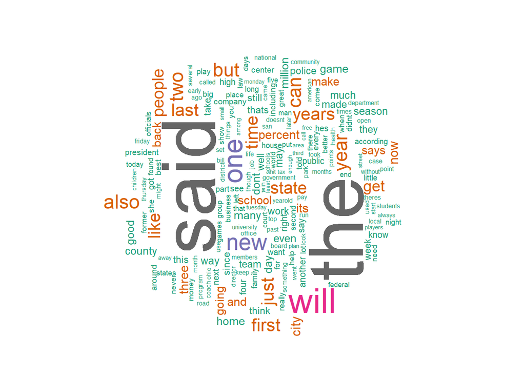

```r
load("corpus.RData")
pal2 <- brewer.pal(8,"Dark2")
wordcloud(corpus, scale=c(6,.2), min.freq=2, max.words=200, random.order=TRUE,
          rot.per=0.5, colors=pal2,  use.r.layout=FALSE)
```

## Tokenizing the Data into a Model

After a great deal of trial and error I ended up tokenizing the data as follows:

1. The sentences are tokenized.
2. Next the sentences are tokenized in ngrams from length two to six.
3. For each length of ngram a dataframe is created as follows:
   1. The last word of each ngram (or the target) is stored in the y column.
   2. The remaining words are reversed and stored in x5 to x1, with the right-hand (or lower numbered) features padded with NAs as appropriate.
   3. A weight column is created containing the number of times the ngram has appeared in the corpus.

This results in five models, one for each length of ngram, which are combined into one large model.

```r
# Create an empty data frame
ngrams <- data.frame(x1=character(),
                     x2=character(),
                     x3=character(),
                     x4=character(),
                     x5=character(),
                     y=character(),
                     weight=integer(),
                    stringsAsFactors=TRUE)

# Create ngrams from the text
for(i in 2:6){
    ngramfreq <- createngrams(text, i)
    model <- createmodel(ngramfreq, 6)
    ngrams <- rbind(ngrams, model)
    rm("ngramfreq","model")
}

# Reorder the columns
columns <- c("x5","x4","x3","x2","x1","y","weight")
ngrams <- ngrams[columns]
```

The reason for reversing the strings is that I believe that the words closest to the end of the input are the most important for predicting the next word. By starting at the end and working our way backwards through the input we can immediately remove any ngrams which do not fit the input and then narrow the results down as we work backwards. The direction will become important when the prediction algorithm is described below, especially as concerning the flexibility to omit words which do not exist in the model.

### Cleaning the Model

Function cleanmodel takes in a list of ngrams and a threshhold and keeps only threshhold y’s for each unique combination of x’s. Since I will return three predictions for each input string there is no need to keep more than three rows for each unique ngram. The ngrams with the highest weight are kept.

```r
# Clean the dataframe
ngrams <- cleanmodel(ngrams, 3)
```

### Removing Misspelled or Nonexistent Words

I noticed that many of the ngrams contained either misspelled words, non-English words or other combinations of characters which were not recognizable as English. To address this I downloaded a list of 450,000 valid English words and filtered the ngrams with it.

```r
# Load valid words
words <- read.csv("words.txt")
words <- words$X2
words <- tolower(words)

# Create a list of unique words from the model
wordlist <- c(as.character(ngrammodel$y), as.character(ngrammodel$x5), as.character(ngrammodel$x4), as.character(ngrammodel$x3), as.character(ngrammodel$x2), as.character(ngrammodel$x1))
wordlist <- unique(wordlist)

# Create a list of words which are NOT valid words
filter <- apply(as.matrix(wordlist),1,checkword)
bad_words <- wordlist[!filter]
bad_words <- unique(bad_words)
```

I started by removing all rows which contained invalid words in the y column, as I do not want the model to predict words which don’t exist.

```r
y <- ngrammodel$y
filter <- unlist(lapply(as.character(y), function(x) x %in% bad_words))
ngrammodel <- ngrammodel[!filter,]

# Rename the rows
rownames(ngrammodel) <- 1:nrow(ngrammodel)
```

I was ambivalent about cleaning the other columns, as non-existent words would not negatively effect the outcome of the algorithm and could only benefit the predictions if a user happens to type in a non-valid word. In the end I did clean the other columns for the purpose of getting the data down to a reasonable size, and included logic for handling words which were not recognized in the prediction model.

### Weighting

As there are far more possibilities for longer ngrams than for shorter ones, the shorter ngrams had far higher frequencies than longer ones, and thus much higher weights. The most frequent bigrams occured as many as 20,000 times in the data, while the maximum frequency for six-grams was closer to ten. Both the mean and median for frequency of ngrams of any length were 1 or close to 1.

```r
ngrammodel <- scaleweight(ngrams)
```

Longer ngrams should generally have a higher weight than shorter ones as they will tend to represent better predictions. I considered scaling the weights accordingly, but in the end decided that this issue could be handled in the logic of the prediction function, which is described below.

## Creating a Prediction Algorithm

I attempted to fit some decision trees to the data, but the RAM required to do so far exceeded the RAM available on my machine. After much trial and error I decided on the model created above, as it provided a reasonable balance of power and flexibility when combined with the prediction algorithm.

The prediction algorithm works as follows:

1. For an input string x:
   1. x is converted to lowercase
   2. punctuation and numbers are removed
   3. the string is tokenized and the last 5 elements are retained.
2. The ngrammodel is copied into a temporary variable.
3. The individual words in the string are looped through:
   1. For each word, the ngrammodel is subsetted to include only ngrams which contain that word in that position.
   2. If there are results, the results are kept. Otherwise the word is skipped and that word is ignored.*
   3. If there are three or fewer unique y’s in the data set the loop is exited and the results returned. Otherwise the loop continues.
4. With the remaining subset of the ngrams, duplicate y’s are filtered out, keeping the results with longer ngrams.
5. The remaining items are sorted by weight descending, and the top 3 ys are returned.
- This allows the algorithm to return matches for ngrams which do not exactly match the existing data. If an ngram which exactly matches the input is not found, the word is ignored and the loop continues. The quality of the prediction will be lower, but that is preferable to not returning and predictions.

The prediction function follows:

```r
# create a prediction function
predictText <- function(x){
    string <- tolower(x)
    string <- removeNumbers(string)
    string <-removePunctuation(string)
    string <- strsplit(string, " ")
    string <- rev(string[[1]])[1:5]
    len <- length(string)

    # Try an easier way
    i <- 1
    matches <- ngrammodel
    for(word in string){
        if(!is.na(word)){
            # Added check for NA to try to prevent overfitting
            # | is.na(matches[,i])
            temp <- subset(matches, (matches[,i] == word  ))

            # if we have matches keep them, otherwise skip the word and continue
            if(nrow(temp) >= 2){
                matches <- temp
            }

            # Check how many unique ys there are, if we have less than 3 we can break and return
            # and no need to continue looping
            if(length(unique(matches$y)) <= 3){
                break;
            }

            i <- i + 1
        } else {
            break
        }
    }

    # Filter out duplicate ys because they don't add anything
    matches = matches[!duplicated(matches$y, fromLast=TRUE),]

    # sort the matches
    matches <- matches[ order(matches$weight, row.names(matches), decreasing=TRUE), ]

    # Take the top 3
    results <- head(unique(matches$y), 3)
    results <- as.character(results)
    return(results)
}
```

### Weighting Redux

Rather than weighting longer ngrams higher I decided to take care of this in the prediction function. My concern was that with strict subsetting the function would often return no predictions for an input which did not exist in the model. This was addressed by skipping any words which returned no results.

I also attempted to allow for the presence of an NA in any given slot, but this resulted in very low quality matches. The final compromise, as detailed above, was to ignore any word which reduced the size of potential matches to below two.

Ideally I would revisit the weighting as, combined with different logic for handling unknown ngrams, might result in higher quality predictions.

## Usage

### Function

```
source("predictionModel.R")
predictText("i like to")
# [1] "play" "go"   "put"
```

### Shiny Application

A Shiny application was created to feature this algorithm, which is available at https://ericscuccimarra.shinyapps.io/TextPrediction2/.

The application uses a dataset which filters out 75% of the text from the Twitter and Blog data, in order to provide a reasonable response speed. Using more data would provide in better predictions.

### Source Code

The source code is available on my GitHub at https://github.com/escuccim/DataScienceCapstone. Note that this repository contains all of the R scripts I created for this project, some of which are not used.

To create a prediction model follow these steps:

1. loaddata.R - loads the data, preprocesses and clean the data.
2. makeData.R - turns the corpus into an ngram model.
3. cleandata.R - removes invalid words
4. predictionModel.R - contains the function to predict text.

Be aware that running this entire process as is will take a long time and require a lot of CPU and RAM.

The file biggerData.R includes all of the steps to create an ngrammodel, using a larger subset of the data than I originally used.

## Outstanding Issues

- Overfitting - As has been described above, the vast majority of the ngrams occur only once in the corpus. While the algorithm does allow for inputs which do not exactly match an existing ngram, if the input does match an existing ngram the predictions will overfit the data. For example entering “my wife is a” as input will return only one prediction - “nurse.” I had considered removing any ngrams which appeared only once in the corpus to avoid this issue, but as the majority of the ngrams appeared only once this resulted in a very small model with very low quality predictions. The solution to this issue would be more data, which would allow me to filter out rare ngrams while still providing decent matches.
- Size of the data - the model is still relatively large. I feel that some sort of decision tree or neural network would provide far greater flexibility and quality of predictions, however my attempt to fit decision trees required prohibitive amounts of RAM even for the smallest subsets of the data I attempted to use. The prediction algorith I ended up using was an attempt to try to mimic a decision tree.
- Online learning - ideally this algorithm would learn as it is used. Every time a prediction is generated the selected prediction would increase in weight while the unselected predictions would decrease slightly. This would allow the quality of the predictions to improve. If the input text contains ngrams which do not exist in the model, they could also be added. This would allow the algorithm to refine itself as it is used.

## Appendix

### I. Functions

```r
# Split the strings into features
splitngrams <- function(x) {
    strsplit(x, " ")
}

# Turn a character vector of text into a data frame of ngrams with their associated frequency
createngrams <- function(sentences, n, threshold=0){
    ngrams <- tokenize_ngrams(sentences, lowercase=TRUE, n=n, n_min=n, simplify=TRUE)
    # Unlist it
    ngrams <- unlist(ngrams)
    # Get frequency
    ngramfreq <- as.data.frame(table(ngrams))

    rm("ngrams")
    # Order and save the two grams
    ngramfreq <- ngramfreq[order(-ngramfreq$Freq),]

    if(threshold > 0){
        # Filter out ngrams that only occur once
        filter <- ngramfreq$Freq > threshhold
        ngramfreq = ngramfreq[filter,]
        rm("filter")
    }

    # Return ngram frequency
    return(ngramfreq)
}

createmodel <- function(ngramfreq, cols=6){
    ngramfreq$ngrams <- as.character(ngramfreq$ngrams)

    splits <- splitngrams(ngramfreq$ngrams)
    splits <- do.call(rbind, splits)
    splits <- as.data.frame(splits)

    # Name the columns
    numcols = ncol(splits)
    numfeatures = numcols - 1
    names(splits)[numcols] <- "y"
    nums <- (cols+1-numcols):(5)
    names = c(paste("x",nums,sep=""),"y")
    names(splits) <- names

    splits$weight <- (ngramfreq$Freq)
    ngrammodel <- splits

    # Order the data frame by weight
    ngrammodel <- ngrammodel[with(ngrammodel, order(x5,-weight)),]

    # Reindex it
    rownames(ngrammodel) <- 1:nrow(ngrammodel)

    # Add cols with NAs where appropriate
    if(numcols < cols){
        newcols = 1:(cols-numcols)
        newcolnames = paste("x",newcols,sep="")
        ngrammodel[,newcolnames] <- NA
    }

    return(ngrammodel)
}

# Since we only return the top three matches we only need to keep the top 3 ys for each combination of x's
cleanmodel <- function(model, threshhold=3) {
    numx <- ncol(model) - 2
    xcols <- 1:numx
    cols <- paste("x", xcols, sep="")
    # Create an empty dataframe with same columns
    newmodel <- model[0,]

    # Get unique combinations of cols
    uniqueRows <- unique(model[cols])
    filter = rep(FALSE, nrow(model))
    fillvalues = rep(TRUE, threshhold)

    for( i in rownames(uniqueRows) ){
        i <- as.numeric(i)
        filter[i:(i+2)] <- TRUE
    }
    model <- model[filter,]

    # Drop the last two rows because they are empty
    nrows <- nrow(model)
    model <- model[1:(nrows-2),]
    # Renumber the rows
    rownames(model) <- 1:nrow(model)
    return(model)
}

cleanData <- function(data){
    data <- removeNumbers(data)
    data <- removePunctuation(data)
    data
}

pad  <- function(x, n) {
    len.diff <- n - length(x)
    c(x, rep(NA, len.diff))
}

checkword <- function(word){
    return(word %in% words)
}

scaleweight <- function(ngrams){
    ngrams$weight <- log10(ngrams$weight)
    ngrams$weight <- ngrams$weight + 0.1
    return(ngrams)
}

# remove non-words
checkwords <- function(list){
    if(!exists("words")){
        words <- valid_word_list("words.txt")
    }

    filter <- apply(as.matrix(list),1,checkword)
    return(filter)
}

# make a model for a maximum of six-grams from a given text corpus.
# threshhold specifies a minimum required number of occurences in the text of an ngram
makedata <- function(text, threshhold=0) {
    sentences <- unlist(tokenize_sentences(text))
    rm(text)

    # Create an empty data frame
    ngrams <- data.frame(x1=character(),
                         x2=character(),
                         x3=character(),
                         x4=character(),
                         x5=character(),
                         y=character(),
                         weight=integer(),
                         stringsAsFactors=TRUE)

    # Create ngrams from the text
    for(i in 2:6){
        ngramfreq <- createngrams(sentences, i, threshhold)
        if(threshhold > 0){
            ngramfreq <- subset(ngramfreq, ngramfreq$Freq > threshhold)
        }
        model <- createmodel(ngramfreq, 6)
        ngrams <- rbind(ngrams, model)
        rm("ngramfreq","model")
    }
    rm("text")

    # Reorder the columns
    columns <- c("x5","x4","x3","x2","x1","y","weight")
    ngrams <- ngrams[columns]

    return(ngrams)
}
```

## II - Removing Invalid Words

```r
# For an ngrammodel and a list of INVALID words, remove any rows which contain invalid words
validateWords <- function(ngrammodel, bad_words) {
    y <- ngrammodel$y
    filter <- unlist(lapply(as.character(y), function(x) x %in% bad_words))
    ngrammodel <- ngrammodel[!filter,]

    x5 <- ngrammodel$x5
    filter <- unlist(lapply(as.character(x5), function(x) x %in% bad_words))
    ngrammodel <- ngrammodel[!filter,]
    rm(x5)

    x4 <- ngrammodel$x4
    filter <- unlist(lapply(as.character(x4), function(x) x %in% bad_words))
    ngrammodel <- ngrammodel[!filter,]
    rm(x4)

    x3 <- ngrammodel$x3
    filter <- unlist(lapply(as.character(x3), function(x) x %in% bad_words))
    ngrammodel <- ngrammodel[!filter,]
    rm(x3)

    x2 <- ngrammodel$x2
    filter <- unlist(lapply(as.character(x2), function(x) x %in% bad_words))
    ngrammodel <- ngrammodel[!filter,]
    rm(x2)

    x1 <- ngrammodel$x1
    filter <- unlist(lapply(as.character(x1), function(x) x %in% bad_words))
    ngrammodel <- ngrammodel[!filter,]
    rm(x1)

    rownames(ngrammodel) <- 1:nrow(ngrammodel)

    return(ngrammodel)
}

# Get list of unique words
uniquewords <- function(ngrammodel){
    wordlist <- c(as.character(ngrammodel$y), as.character(ngrammodel$x5), as.character(ngrammodel$x4), as.character(ngrammodel$x3), as.character(ngrammodel$x2), as.character(ngrammodel$x1))
    wordlist <- unique(wordlist)
    return(wordlist)
}

# Get list of which words are NOT valid
invalid_word_list <- function(wordlist){
    filter <- apply(as.matrix(wordlist),1,checkword)
    bad_words <- wordlist[!filter]
    bad_words <- unique(bad_words)
    return(bad_words)
}

# create a vector of valid words from a text list
valid_word_list <- function(file) {
    words <- read.csv(file)
    words <- tolower(words$X2)
    save(words, file="validwords.RData")
    return(words)
}
```